# Take Home Final Exam

For the take-home part of the MSDS 401 Final Exam, you are tasked with analyzing data on new daily covid-19 cases and deaths in European Union (EU) and European Economic Area (EEA) countries. A data file may be downloaded [here](https://www.ecdc.europa.eu/en/publications-data/data-daily-new-cases-covid-19-eueea-country), *or* you may use the provided **read.csv()** code in the ‘setup’ code chunk below to read the data directly from the web csv. Either approach is acceptable; the data should be the same.

Once you have defined a data frame with the daily case and death and country data, you are asked to: (1) perform an Exploratory Data Analysis (EDA), (2) perform some hypothesis testing, (3) perform some correlation testing, and (4) fit and describe a linear regression model. Each of these four (4) items is further explained below and “code chunks” have been created for you in which to add your R code, just as with the R and Data Analysis Assignments. You may add additional code chunks, as needed. You should make comments in the code chunks or add clarifying text between code chunks that you think further your work.

A data dictionary for the dataset is available [here](https://www.ecdc.europa.eu/sites/default/files/documents/Description-and-disclaimer_daily_reporting.pdf).

#### Definitions:

- “Incidence rate” is equal to new daily cases per 100K individuals. Country population estimates can be found in ‘popData2020.’ You will calculate a daily incidence rate in item (1), for each country, that we will explore further in items (2) and (3).
- “Fatality rate” is equal to new daily deaths per 100K individuals. Country population estimates can be found in ‘popData2020.’ You will calculate a daily fatality rate in item (1), for each country, that we will explore further in items (2) and (3).

#### 1. Descriptive Statistics

Perform an Exploratory Data Analysis (EDA). Your EDA is exactly that: yours. Your knit .html should include the visualizations and summary tables that you find valuable while exploring this dataset. **However**, at minimum, your EDA must include the following:

- Creation of a vector, ‘incidence_rate,’ equal to the daily new cases per 100K individuals, per country. Country populations are provided in ‘popData2020.’ This vector should be added to the ‘data’ data frame.
- Creation of a vector, ‘fatality_rate,’ equal to the new deaths per 100K individuals, per country. Country populations are provided in ‘popData2020.’ This vector should be added to the ‘data’ data frame.
- A visualization exploring new cases or incidence rates, per country, over time. You may choose a subset of countries, if you wish, but your visualization should include at least five (5) countries and include the entire time frame of the dataset.
- A visualization exploring new deaths or fatality rates, per country, over time. You may choose a subset of countries, if you wish, but your visualization should include at least five (5) countries.
- A table or visualization exploring some other aspect of the data. For example, you could explore case fatality rates per country; the number of deaths divided by the total number of cases. Note that to do this, you would want to like across the entire time of the dataset, looking at the total cases and deaths, per country.

```r
## Exploratory Data Analysis

summary(data)
```

```
##     dateRep                day            month             year
##  Min.   :2020-01-01   Min.   : 1.00   Min.   : 1.000   Min.   :2020
##  1st Qu.:2020-10-17   1st Qu.: 8.00   1st Qu.: 4.000   1st Qu.:2020
##  Median :2021-06-17   Median :16.00   Median : 6.000   Median :2021
##  Mean   :2021-06-17   Mean   :15.68   Mean   : 6.431   Mean   :2021
##  3rd Qu.:2022-02-13   3rd Qu.:23.00   3rd Qu.: 9.000   3rd Qu.:2022
##  Max.   :2022-10-26   Max.   :31.00   Max.   :12.000   Max.   :2022
##
##      cases             deaths         countriesAndTerritories     geoId
##  Min.   :-348846   Min.   : -217.00   Finland  : 1024         FI     : 1024
##  1st Qu.:    111   1st Qu.:    0.00   France   : 1006         FR     : 1006
##  Median :    705   Median :    5.00   Czechia  : 1003         CZ     : 1003
##  Mean   :   6088   Mean   :   40.87   Lithuania:  997         LT     :  997
##  3rd Qu.:   3483   3rd Qu.:   31.00   Germany  :  992         DE     :  992
##  Max.   : 501635   Max.   :13743.00   Sweden   :  982         SE     :  982
##  NA's   :93        NA's   :292        (Other)  :22725         (Other):22725
##  countryterritoryCode  popData2020
##  FIN    : 1024        Min.   :   38747
##  FRA    : 1006        1st Qu.: 2095861
##  CZE    : 1003        Median : 6951482
##  LTU    :  997        Mean   :15348035
##  DEU    :  992        3rd Qu.:11522440
##  SWE    :  982        Max.   :83166711
##  (Other):22725
```

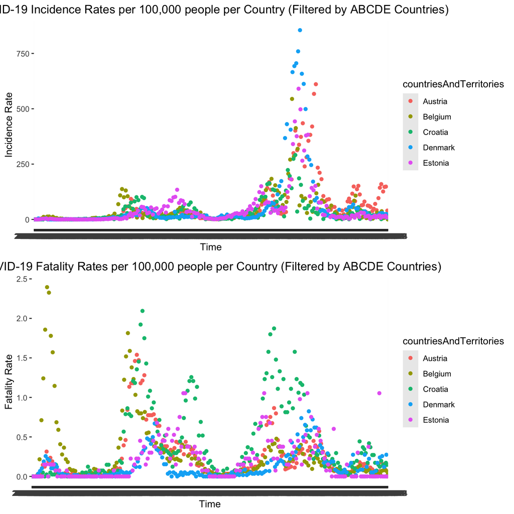

```r
data$incidence_rate <- (data$cases/data$popData2020)*100000
data$fatality_rate <- (data$deaths/data$popData2020)*100000

plotdata1 <- filter(data, countriesAndTerritories == c("Austria", "Belgium", "Croatia", "Denmark", "Estonia"))

p1 <- ggplot(data=plotdata1,aes(x=as.character(dateRep),y=incidence_rate,group=countriesAndTerritories)) +
  geom_point(aes(color=countriesAndTerritories)) +
  ggtitle("COVID-19 Incidence Rates per 100,000 people per Country (Filtered by ABCDE Countries)") +
  theme(plot.title = element_text(hjust = .5)) +
  xlab("Time") +
  ylab("Incidence Rate") +
  scale_fill_brewer(palette='Spectral')

p2 <- ggplot(data=plotdata1,aes(x=as.character(dateRep),y=fatality_rate,group=countriesAndTerritories)) +
  geom_point(aes(color=countriesAndTerritories)) +
  ggtitle("COVID-19 Fatality Rates per 100,000 people per Country (Filtered by ABCDE Countries)") +
  theme(plot.title = element_text(hjust = .5)) +
  xlab("Time") +
  ylab("Fatality Rate") +
  scale_fill_brewer(palette='Spectral')

grid.arrange(p1, p2)
```

#### 2. Inferential Statistics

Select two (2) countries of your choosing and compare their incidence or fatality rates using hypothesis testing. At minimum, your work should include the following:

- Visualization(s) comparing the daily incidence or fatality rates of the selected countries,
- A statement of the null hypothesis.
- A short justification of the statistical test selected.
  - Why is the test you selected an appropriate one for the comparison we’re making?
- A brief discussion of any distributional assumptions of that test.
  - Does the statistical test we selected require assumptions about our data?
  - If so, does our data satisfy those assumptions?
- Your selected alpha.
- The test function output; i.e. the R output.
- The relevant confidence interval, if not returned by the R test output.
- A concluding statement on the outcome of the statistical test.
  - i.e. Based on our selected alpha, do we reject or fail to reject our null hypothesis?

[figure not shown]

```r
## Inferential Statistics

# Countries of Interest: Austria & Belgium

plotdata2 <- filter(data, countriesAndTerritories == c("Austria", "Belgium"))

p3 <- ggplot(data=plotdata2,aes(x=as.character(dateRep),y=fatality_rate,group=countriesAndTerritories)) +
  geom_line(aes(color=countriesAndTerritories)) +
  ggtitle("COVID-19 Incidence Rates per 100,000 people per Country (Filtered by ABCDE Countries)") +
  theme(plot.title = element_text(hjust = .5)) +
  xlab("Time") +
  ylab("Incidence Rate") +
  scale_fill_brewer(palette='Spectral')


p4 <- ggplot(data=plotdata2,aes(x=as.character(dateRep),y=fatality_rate,group=countriesAndTerritories)) +
  geom_line(aes(color=countriesAndTerritories)) +
  ggtitle("COVID-19 Fataltiy Rates per 100,000 people per Country (Filtered by ABCDE Countries)") +
  theme(plot.title = element_text(hjust = .5)) +
  xlab("Time") +
  ylab("Fatality Rate") +
  scale_fill_brewer(palette='Spectral')

grid.arrange(p3, p4)
```

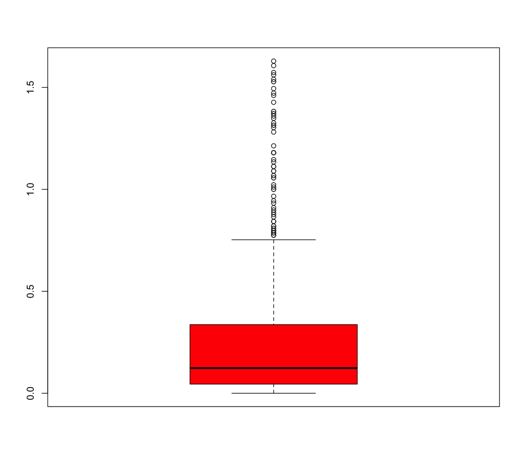

```r
# Hypothesis Testing, where:
# m1 = avg fatality rate in Austria
# m2 = avg fatality rate in Belgium
# Null Hypothesis: m1 = m2
# Alternative Hypothesis: m1 != m2
# Thus, we are testing if the fatality rates (average) in Austria differ from Belgium

# Subset data
a_data <- subset(data, countriesAndTerritories == "Austria")
b_data <- subset(data, countriesAndTerritories == "Belgium")

# Check Normality of Distribution with Box Plot

b1 <- boxplot(a_data$fatality_rate, col="red")
```

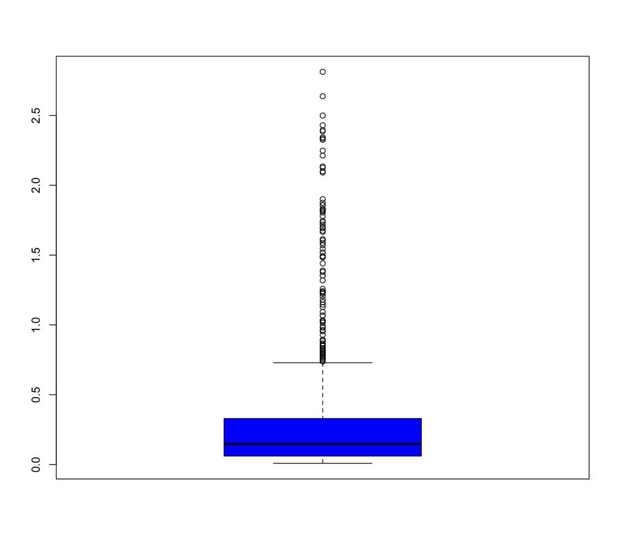

```r
b2 <- boxplot(b_data$fatality_rate, col="blue")
```

```r
# Run t-test
t.test(a_data$fatality_rate,b_data$fatality_rate, conf.level = 0.95, alternative ="two.sided", var.equal = FALSE)
```

```
##
##  Welch Two Sample t-test
##
## data:  a_data$fatality_rate and b_data$fatality_rate
## t = -3.3689, df = 1697.5, p-value = 0.0007716
## alternative hypothesis: true difference in means is not equal to 0
## 95 percent confidence interval:
##  -0.09171484 -0.02421876
## sample estimates:
## mean of x mean of y
## 0.2418045 0.2997713
```

```r
# Conclusion
# Given the Confidence Level of 0.95, there is an alpha of 0.05. Due to the alternative hypothesis being != instead of <= or >=, this will be a two-sided t-test. The resulted p-value is 0.0007716, which is almost zero. Conclusively, we can reject the null hypothesis that the avg fatality rate in Austria is equal to that of Belgium.
```